```python
import pandas as pd
!pip install lxml
```

```python
import requests
from bs4 import BeautifulSoup

r = requests.get('https://www.ers.usda.gov/data-products/fruit-and-vegetable-prices/fruit-and-vegetable-prices/#Archived%20Fruit%20and%20Vegetable%20Prices%20Tables')
soup = BeautifulSoup( r.content )
```

```python
r = requests.get('https://fred.stlouisfed.org/series/A576RC1')
soup1 = BeautifulSoup( r.content )
```

# US Cost of Living, Inflation, and Salary comparison

### H. Jacob Schenck | Tulane CMPS 6790 Fall 2024

[Website Link](https://hjschenck.github.io/)

# Project Outline

In the United States, the [economy](https://www.pewresearch.org/politics/2024/09/09/issues-and-the-2024-election/) was the #1 vote issue in the 2024 Presidential Election. This project will analyze and compare common economic and cost of living metrics provided by the federal government to determine if these metrics are accurate and representative of the economy as a whole. These metrics are:

- Inflation Rate
- Inflation Rate (derived directly from consumer goods)
- Household Income
- Housing Prices

Which will be taken from the USDA and the FRED.

Many people complain about inflation and the cost of living rising in the United States at an unmanageable rate, which would explain why the economy is so important to the average voter. However, are complaints about inflation valid? Is inflation higher than it seems or is officially listed? Hopefully, we can address these questions and find out why Americans think the economy is such an important issue.

Data used:  
[Fruit and Vegetable prices](https://www.ers.usda.gov/data-products/fruit-and-vegetable-prices/fruit-and-vegetable-prices/#Archived%20Fruit%20and%20Vegetable%20Prices%20Tables): USDA  
[Inflation](https://fred.stlouisfed.org/series/FPCPITOTLZGUSA#0),[Housing](https://fred.stlouisfed.org/series/USSTHPI#0),[Income](https://fred.stlouisfed.org/series/MEHOINUSA672N#0): FRED

The following scripts grab all the necessary data and imports it.

```python
csvs = []
links = soup.find("table", {"class": "usa-table usa-table--striped usa-table--stacked-header usa-table--borderless"}).find_all('a')
for l in links:
    # Just get the reference link
    href = l['href']
    # If it's a CSV file, save it...
    if '.csv' in href.lower():  # Check if .csv appears anywhere in the link
        csvs.append(href)
print(csvs)
```

```python
zips = []
links = soup.find("table", {"class": "usa-table usa-table--striped usa-table--stacked-header usa-table--borderless"}).find_all('a')
for l in links:
    # Just get the reference link
    href = l['href']
    # If it's a ZIP file, save it...
    if '.zip' in href.lower():
        zips.append(href)

print(zips)
```

```python
from urllib.parse import urljoin, urlparse
import os

base_url = "https://www.ers.usda.gov/data-products/fruit-and-vegetable-prices/fruit-and-vegetable-prices/#Archived%20Fruit%20and%20Vegetable%20Prices%20Tables"

for href in csvs:
    urld = urljoin(base_url, href)
    print(urld)
    rd = requests.get(urld, stream=True)

    parsed_url = urlparse(href)
    filename = os.path.basename(parsed_url.path) #government website moment, get ride of the ?v=(num) AFTER the .csv
    outfile = os.path.join("./", filename)
    print("Writing: ",outfile)
    with open(outfile, 'wb') as f:
        f.write(rd.content)
```

```python
from io import StringIO
url = "https://fred.stlouisfed.org/graph/fredgraph.csv?bgcolor=%23e1e9f0&chart_type=line&drp=0&fo=open%20sans&graph_bgcolor=%23ffffff&height=450&mode=fred&recession_bars=on&txtcolor=%23444444&ts=12&tts=12&width=1140&nt=0&thu=0&trc=0&show_legend=yes&show_axis_titles=yes&show_tooltip=yes&id=MEHOINUSA672N&scale=left&cosd=1984-01-01&coed=2023-01-01&line_color=%234572a7&link_values=false&line_style=solid&mark_type=none&mw=3&lw=2&ost=-99999&oet=99999&mma=0&fml=a&fq=Annual&fam=avg&fgst=lin&fgsnd=2020-02-01&line_index=1&transformation=lin&vintage_date=2024-10-27&revision_date=2024-10-27&nd=1984-01-01"

rd = requests.get(url)

parsed_url = urlparse(href)
filename = "FREDHouseholdIncome.csv"

outfile = os.path.join("./", filename)

with open(outfile, 'wb') as f:
    for chunk in rd.iter_content(chunk_size=8192):
         f.write(chunk)
```

```python
from io import StringIO
url = "https://fred.stlouisfed.org/graph/fredgraph.csv?bgcolor=%23e1e9f0&chart_type=line&drp=0&fo=open%20sans&graph_bgcolor=%23ffffff&height=450&mode=fred&recession_bars=on&txtcolor=%23444444&ts=12&tts=12&width=1140&nt=0&thu=0&trc=0&show_legend=yes&show_axis_titles=yes&show_tooltip=yes&id=FPCPITOTLZGUSA&scale=left&cosd=1960-01-01&coed=2023-01-01&line_color=%234572a7&link_values=false&line_style=solid&mark_type=none&mw=3&lw=2&ost=-99999&oet=99999&mma=0&fml=a&fq=Annual&fam=avg&fgst=lin&fgsnd=2020-02-01&line_index=1&transformation=lin&vintage_date=2024-10-27&revision_date=2024-10-27&nd=1960-01-01"

rd = requests.get(url)

parsed_url = urlparse(href)
filename = "FREDInflation.csv"

outfile = os.path.join("./", filename)

with open(outfile, 'wb') as f:
    for chunk in rd.iter_content(chunk_size=8192):
         f.write(chunk)
```

```python
from io import StringIO
url = "https://fred.stlouisfed.org/graph/fredgraph.csv?bgcolor=%23e1e9f0&chart_type=line&drp=0&fo=open%20sans&graph_bgcolor=%23ffffff&height=450&mode=fred&recession_bars=on&txtcolor=%23444444&ts=12&tts=12&width=1140&nt=0&thu=0&trc=0&show_legend=yes&show_axis_titles=yes&show_tooltip=yes&id=MEHOINUSA672N&scale=left&cosd=1984-01-01&coed=2023-01-01&line_color=%234572a7&link_values=false&line_style=solid&mark_type=none&mw=3&lw=2&ost=-99999&oet=99999&mma=0&fml=a&fq=Annual&fam=avg&fgst=lin&fgsnd=2020-02-01&line_index=1&transformation=pch&vintage_date=2024-10-27&revision_date=2024-10-27&nd=1984-01-01"
rd = requests.get(url)

parsed_url = urlparse(href)
filename = "FREDHouseholdIncomePercent.csv"

outfile = os.path.join("./", filename)

with open(outfile, 'wb') as f:
    for chunk in rd.iter_content(chunk_size=8192):
         f.write(chunk)
```

```python
from io import StringIO
url = "https://fred.stlouisfed.org/graph/fredgraph.csv?bgcolor=%23e1e9f0&chart_type=line&drp=0&fo=open%20sans&graph_bgcolor=%23ffffff&height=450&mode=fred&recession_bars=on&txtcolor=%23444444&ts=12&tts=12&width=1140&nt=0&thu=0&trc=0&show_legend=yes&show_axis_titles=yes&show_tooltip=yes&id=USSTHPI&scale=left&cosd=1975-01-01&coed=2024-04-01&line_color=%234572a7&link_values=false&line_style=solid&mark_type=none&mw=3&lw=2&ost=-99999&oet=99999&mma=0&fml=a&fq=Annual&fam=avg&fgst=lin&fgsnd=2020-02-01&line_index=1&transformation=pch&vintage_date=2024-10-27&revision_date=2024-10-27&nd=1975-01-01"
rd = requests.get(url)

parsed_url = urlparse(href)
filename = "FREDHousePricePercent.csv"

outfile = os.path.join("./", filename)

with open(outfile, 'wb') as f:
    for chunk in rd.iter_content(chunk_size=8192):
         f.write(chunk)
```

```python
import zipfile
import io

for zip_url in zips:
    urld = urljoin(base_url, zip_url)
    print(urld)
    rd = requests.get(urld, stream=True)

    #same for the Zips, extract then write.
    with zipfile.ZipFile(io.BytesIO(rd.content)) as z:
        for file in z.namelist():
            if file.endswith(".csv"):
                outfile = os.path.join("./", file.split("/")[-1])
                z.extract(file, path=outfile)
```

```python
#read in all the csvs we need
v20 = pd.read_csv("Vegetable Prices 2020.csv")
v22 = pd.read_csv("Vegetable-Prices-2022.csv")
f20 = pd.read_csv("Fruit Prices 2020.csv")
f22 = pd.read_csv("Fruit-Prices-2022.csv")
f22.head()
```

|  | Fruit | Form | RetailPrice | RetailPriceUnit | Yield | CupEquivalentSize | CupEquivalentUnit | CupEquivalentPrice |
| --- | --- | --- | --- | --- | --- | --- | --- | --- |
| 0 | Apples | Fresh | 1.8541 | per pound | 0.90 | 0.2425 | pounds | 0.4996 |
| 1 | Apples, applesauce | Canned | 1.1705 | per pound | 1.00 | 0.5401 | pounds | 0.6323 |
| 2 | Apples, ready-to-drink | Juice | 0.8699 | per pint | 1.00 | 8.0000 | fluid ounces | 0.4349 |
| 3 | Apples, frozen concentrate | Juice | 0.6086 | per pint | 1.00 | 8.0000 | fluid ounces | 0.3043 |
| 4 | Apricots | Fresh | 3.6162 | per pound | 0.93 | 0.3638 | pounds | 1.4145 |

The data from the USDA is structured as:

- **Fruit/Vegetable/etc**: The kind of food
- **Form**: The form it is sold in (can, fresh, etc)
- **RetailPrice**: The retail price of the item, on average, for the given year.
- **RetailPriceUnit**: The unit the price is being measured in. So if RetailPrice is 2.00 and RetailPriceUnit is per pound, the product is being sold for 2 dollars a pound
- **Yield**: Is an approximate measure of what percentage of the product is actually usable, so only about 90 percent of an apple is edible food.
- **CupEquivalentSize**: The size of the item converted to cups
- **CupEquivalentUnit**: The unit used in the conversion(usually the same as or equivalent to RetailPriceUnit)
- **CupEquivalentPrice**: The standardized cost of the item in cups

```python
FredHI = pd.read_csv("FREDHouseholdIncome.csv")
FredI = pd.read_csv("FREDInflation.csv")
FredHIP = pd.read_csv("FREDHouseholdIncomePercent.csv")
FredHPP = pd.read_csv("FREDHousePricePercent.csv")
FredHPP.head()
```

|  | DATE | USSTHPI_PCH |
| --- | --- | --- |
| 0 | 1976-01-01 | 7.24080 |
| 1 | 1977-01-01 | 12.16031 |
| 2 | 1978-01-01 | 13.99646 |
| 3 | 1979-01-01 | 13.61832 |
| 4 | 1980-01-01 | 7.90573 |

The data from the FRED is structured as:

- **DATE**: period of time the measurement was taken
- **The Thing Being Measured**: The thing being measured, such as inflation

First, for readibility and ease of use, the columns in the dataframes should be renamed.

```python
#standardize column name
v20 = v20.rename(columns={"Vegetable": "Food"})
v22 = v22.rename(columns={"Vegetable": "Food"})
f20 = f20.rename(columns={"Fruit": "Food"})
f22 = f22.rename(columns={"Fruit": "Food"})
FredHI = FredHI.rename(columns={"DATE": "Year", "MEHOINUSA672N": "Income"})
FredHIP = FredHIP.rename(columns={"DATE": "Year", "MEHOINUSA672N_PCH": "IncomePercent"})
FredI = FredI.rename(columns={"DATE": "Year", "FPCPITOTLZGUSA": "Inflation"})
FredHPP = FredHPP.rename(columns={"DATE": "Year", "USSTHPI_PCH": "HousePricePercent"})
```

Now, the uneeded data is dropped, and the dataframes for consumer goods are combined into one dataframe for ease of use

```python
#drop and merge
v20 = v20.drop(columns=["RetailPriceUnit", "Yield", "CupEquivalentSize", "CupEquivalentUnit", "CupEquivalentPrice"])
v22 = v22.drop(columns=["RetailPriceUnit", "Yield", "CupEquivalentSize", "CupEquivalentUnit", "CupEquivalentPrice"])
f20 = f20.drop(columns=["RetailPriceUnit", "Yield", "CupEquivalentSize", "CupEquivalentUnit", "CupEquivalentPrice"])
f22 = f22.drop(columns=["RetailPriceUnit", "Yield", "CupEquivalentSize", "CupEquivalentUnit", "CupEquivalentPrice"])
```

```python
vdf = v20.merge(v22, on=["Food", "Form"], suffixes=("2020", "2022"))
fdf = f20.merge(f22, on=["Food", "Form"], suffixes=("2020", "2022"))
```

```python
df = fdf.merge(vdf, on=["Food", "Form", "RetailPrice2020", "RetailPrice2022"], how="outer")
```

```python
df
```

|  | Food | Form | RetailPrice2020 | RetailPrice2022 |
| --- | --- | --- | --- | --- |
| 0 | Apples | Fresh | 1.5193 | 1.8541 |
| 1 | Apples, applesauce | Canned | 1.0660 | 1.1705 |
| 2 | Apples, ready-to-drink | Juice | 0.7804 | 0.8699 |
| 3 | Apples, frozen concentrate | Juice | 0.5853 | 0.6086 |
| 4 | Apricots | Fresh | 2.9665 | 3.6162 |
| ... | ... | ... | ... | ... |
| 149 | Tomatoes | Canned | 1.0175 | 1.0715 |
| 150 | Turnip greens | Fresh | 2.4176 | 2.9250 |
| 151 | Turnip greens | Canned | 1.0429 | 1.3154 |
| 152 | Turnip greens | Frozen | 1.9451 | 2.5169 |
| 153 | Zucchini | Fresh | 1.5489 | 1.6359 |

154 rows × 4 columns

Now, we have a dataframe with the prices of certain types of goods on average over a given period of time.

For the FRED data, the data needs to be formatted better for ease of use, as all data is listed as having been collected at the beginning of the year, so the exact date is irrelevant.

```python
FredHI['Year'] = FredHI['Year'].str.replace(r'-01-01$', '', regex=True)
FredHIP['Year'] = FredHIP['Year'].str.replace(r'-01-01$', '', regex=True)
FredI['Year'] = FredI['Year'].str.replace(r'-01-01$', '', regex=True)
FredHPP['Year'] = FredHPP['Year'].str.replace(r'-01-01$', '', regex=True)
FredHPP.head()
```

|  | Year | HousePricePercent |
| --- | --- | --- |
| 0 | 1976 | 7.24080 |
| 1 | 1977 | 12.16031 |
| 2 | 1978 | 13.99646 |
| 3 | 1979 | 13.61832 |
| 4 | 1980 | 7.90573 |

```python
FredHI.dtypes
```

```
Year      object
Income     int64
dtype: object
```

Now, for future ease of use, the years need to be converted to an integer value and the data itself should be standardized as a float value.

```python
FredHI['Year'] = FredHI['Year'].astype(int)
FredHIP['Year'] = FredHIP['Year'].astype(int)
FredI['Year'] = FredI['Year'].astype(int)
FredHPP['Year'] = FredHPP['Year'].astype(int)
```

```python
FredHPP = FredHPP.drop(48)
```

```python
FredHI['Income'] = FredHI['Income'].astype(float)
FredHIP['IncomePercent'] = FredHIP['IncomePercent'].astype(float)
FredI['Inflation'] = FredI['Inflation'].astype(float)
FredHPP['HousePricePercent'] = FredHPP['HousePricePercent'].astype(float)
```

```python
import numpy as np

#get percent increase in price and compare to percent increase in inflation
means = df[["RetailPrice2020", "RetailPrice2022"]].mean()
pct_inc = means.pct_change()
inflation = {'2021': 4.697859 ,'2022': 8.002800}
inf = pd.Series(data=inflation, index=['2021', '2022'])
temp = 1 + (inf / 100)
inflation_sum = np.prod(temp)
total_inflation = (inflation_sum - 1)
(total_inflation,
pct_inc)
pct_inc
```

```
RetailPrice2020         NaN
RetailPrice2022    0.129919
dtype: float64
```

Now we have both the rate of inflation from the FRED and the derived inflation rate from USDA consumer goods from the period from 2020 to 2022, which we can use to see if inflation statistics actually represent how much the price of consumer goods increased over that period of time

```python
#df with average price increase and US official inflation rate
df_new = pd.DataFrame([pct_inc])
df_new = df_new.T
df_new = df_new.rename(columns={0: "Average Price Increase"})
df_new['FRED Inflation'] = pd.Series(dtype='float')
df_new.at['RetailPrice2022','FRED Inflation'] = total_inflation
df_new
```

|  | Average Price Increase | FRED Inflation |
| --- | --- | --- |
| RetailPrice2020 | NaN | NaN |
| RetailPrice2022 | 0.129919 | 0.130766 |

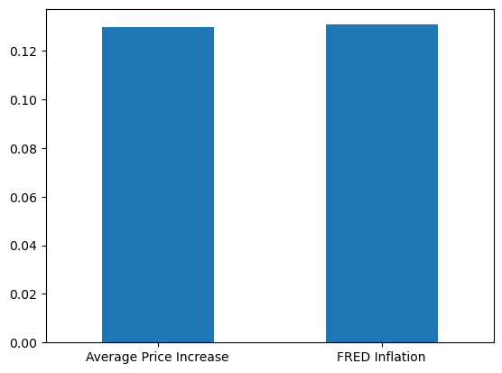

```python
rowplot = df_new.iloc[1]
rowplot.plot.bar(rot=0)
#normally this would be a line plot, but this only compares the two values for one period so this probably is easier to read.
```

## FRED vs Real consumer goods price

The FRED values for inflation thus are pretty clearly aligned with actual consumer good costs and a good indicator of how much more expensive things are getting in general.

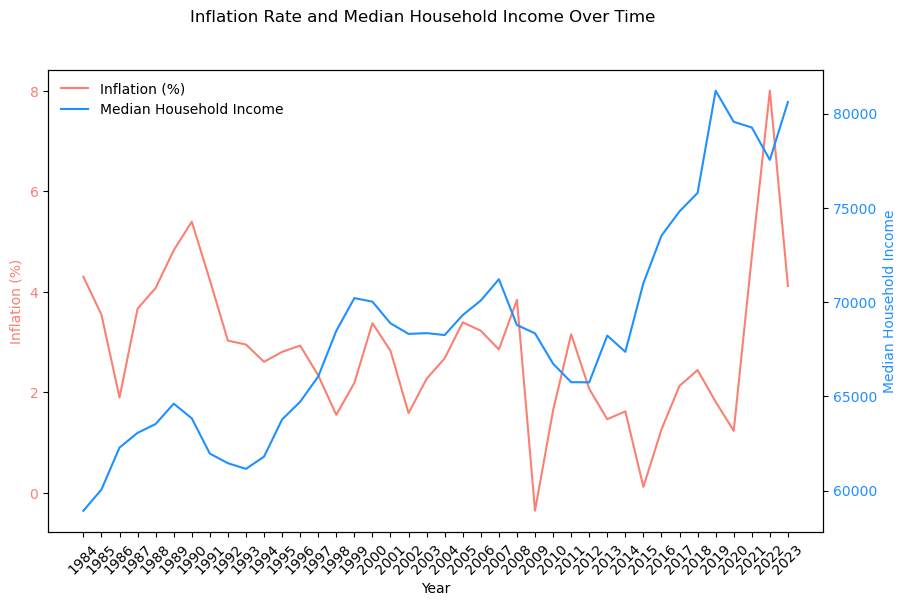

```python
import matplotlib.pyplot as plt
df_combined = pd.merge(FredI, FredHI, on='Year')

fig, ax1 = plt.subplots(figsize=(10, 6))

# first axis
line1, = ax1.plot(df_combined['Year'], df_combined['Inflation'], color='salmon', label='Inflation (%)')
ax1.set_xlabel('Year')
plt.xticks(rotation=45)
ax1.set_ylabel('Inflation (%)', color='salmon')
ax1.tick_params(axis='y', labelcolor='salmon')

# second axis
ax2 = ax1.twinx()
line2, = ax2.plot(df_combined['Year'], df_combined['Income'], color='dodgerblue', label='Median Household Income')
ax2.set_ylabel('Median Household Income', color='dodgerblue')
ax2.tick_params(axis='y', labelcolor='dodgerblue')

# legend
lines = [line1, line2]
labels = [line.get_label() for line in lines]
ax1.legend(lines, labels, loc='upper left', bbox_to_anchor=(0, 1), frameon=False)

fig.suptitle('Inflation Rate and Median Household Income Over Time')

plt.show()
```

## Inflation vs income over time

Although difficult to read, inflation has been going up at a much higher rate than household income. This can be shown in a bar graph over a period of time as a cumulative percent increase.

```python
FredI['Year'] = FredI['Year'].astype(int)
```

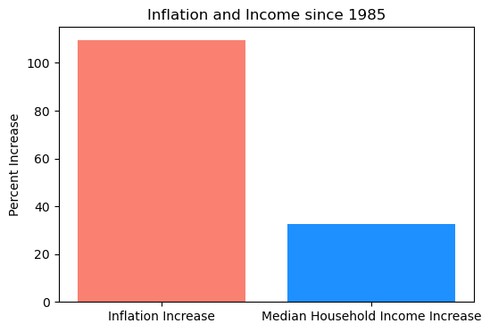

```python
FredI['Year'] = FredI['Year'].astype(int)

InflationSum = FredI[FredI['Year'] >= 1985]['Inflation'].sum() ## get the total percent change over time since 1985
IncomeSum = FredHIP["IncomePercent"].sum()

labels = ['Inflation Increase', 'Median Household Income Increase']
vals = [InflationSum, IncomeSum]

plt.figure(figsize=(6,4)) ## plot it
plt.bar(labels, vals, color=['salmon', 'dodgerblue'])

plt.title('Inflation and Income since 1985')
plt.ylabel('Percent Increase')

plt.show()
```

## Inflation vs Median Household income

The graph speaks for itself, Inflation has gone up more than 100 percent in forty years while median household income has not even increased by 40 percent.

```python
FredHPP['Year'] = FredHPP['Year'].astype(int)
FredHPP['HousePricePercent'] = FredHPP['HousePricePercent'].astype(float)
```

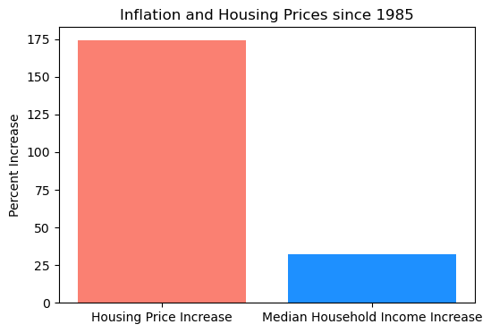

```python
PriceSum = FredHPP[FredHPP['Year'] >= 1985]['HousePricePercent'].sum()

labels = ['Housing Price Increase', 'Median Household Income Increase']
vals = [PriceSum, IncomeSum]

plt.figure(figsize=(6,4))
plt.bar(labels, vals, color=['salmon', 'dodgerblue'])

plt.title('Inflation and Housing Prices since 1985')
plt.ylabel('Percent Increase')

plt.show()
```

## Housing vs Income

Certain sectors, like housing, are not fully captured by the rising price of consumer goods. Housing prices are increasing at an even greater rate than inflation. Going into this project I figured that the wages wouldn't be keeping up but I didn't know it was going to be THIS bad.

## Linear Regression on Income, Inflation, and Housing Costs

The total percentage increase of Median Household Income is obviously lower, but the relation between Income, Inflation, and Housing prices could be modeled by a linear regression, which would show how correlated Income is to the other two economic metrics.

```python
import matplotlib.pyplot as plt
from scipy.stats import linregress
```

```
Slope: -0.21
Intercept: 2.98
R-squared: 0.11
```

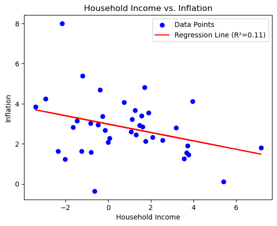

```python
merged_df = pd.merge(FredI, FredHIP, on='Year')

slope, intercept, r_value, p_value, std_err = linregress(merged_df['IncomePercent'], merged_df['Inflation'])
r_squared = r_value**2

print(f"Slope: {slope:.2f}")
print(f"Intercept: {intercept:.2f}")
print(f"R-squared: {r_squared:.2f}")

plt.scatter(merged_df['IncomePercent'], merged_df['Inflation'], color='blue', label='Data Points')

x = merged_df['IncomePercent']
y_line = slope * x + intercept
plt.plot(x, y_line, color='red', label=f'Regression Line (R²={r_squared:.2f})')

plt.xlabel('Household Income')
plt.ylabel('Inflation')
plt.title('Household Income vs. Inflation')
plt.legend()
```

```
Slope: 0.34
Intercept: 4.18
R-squared: 0.03
```

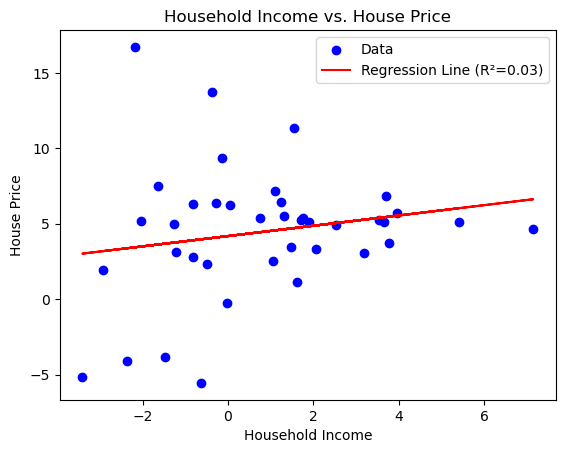

```python
merged_df = pd.merge(FredHPP, FredHIP, on='Year')

slope, intercept, r_value, p_value, std_err = linregress(merged_df['IncomePercent'], merged_df['HousePricePercent'])
r_squared = r_value**2

print(f"Slope: {slope:.2f}")
print(f"Intercept: {intercept:.2f}")
print(f"R-squared: {r_squared:.2f}")

plt.scatter(merged_df['IncomePercent'], merged_df['HousePricePercent'], color='blue', label='Data')

x = merged_df['IncomePercent']
y_line = slope * x + intercept
plt.plot(x, y_line, color='red', label=f'Regression Line (R²={r_squared:.2f})')

plt.xlabel('Household Income')
plt.ylabel('House Price')
plt.title('Household Income vs. House Price')
plt.legend()
```

## Analysis

As you can see, the linear regression model shows that Income is not correlated with Inflation or Housing prices. It would conclude that a significant portion of the comlpaints or worries the American people have about the econonomy are either directly or indirectly related to this fact: Wages are not keeping up. This is of serious concern to anybody invested in the future of America for a number of reasons. Inflation isn't the real problem here, and despite this is often pointed towards as an indicator of economic stability when, by itself, really doesn't say much. If the US, for whatever reason, got rid of cents and changed the lowest denomination to be 1 dollar and everyone multiplied the price of everything by 100 to account for this, inflation would skyrocket to what would appear to be a disasterous level while in reality nothing has substantively changed.

## Conclusions

Economic metrics must always be considered with the context from which they are taken. Inflation by itself means nothing just like salary by itself means nothing. If I tell you the average salary in Japan is 6,200,000 million Yen, that means nothing if you don't also know how much anything actually costs in the country, like education, housing, healthcare, and so on. For America, the inflation by itself isn't a problem, not right now. I posit that stagnating wages, or rather the median household income, are not keeping up with the prices of basic consumer goods or other expensive big ticket items such as housing.